# Temporal trends in mortality and readmission after acute heart failure : A systematic review and meta-regression in the past four decades

Antoine Kimmoun, Thomas Merkling & Etienne Gayat

This code works best if the whole structure deposited on OSF has been downloaded and a R project has been created in the root directory. Figure and table number refer to those in the published paper.

```r
#Packages needed:
require(metafor)
library(readxl)
library(tidyverse) # need the last version of dplyr (1.0.2) to work
library(grid)
library(PropCIs)
library(emmeans) # need the last version (1.5.3) to work
library(broom)
library(flextable)
library(patchwork)
library(rms)
library(maps)
```

```r
# downloading required functions
source("functions/R_functions_Kimmoun_et_al_final.R")
source("functions/rob.summary.R")
```

```r
DATA <- read.csv2("data/clean_data_Kimmoun_et_al.csv", na.strings =c(""," ","NA"))

qos <- data.frame(read_excel("data/qos.xlsx"))

# PMID of MEDICARE studies
MEDICARE_ID <- c(10074960, 16828634, 28719692, 19064833)
```

The results presented here are based on a comprehensive and systematic literature review of AHF studies between 1980 and 2017 in which acute heart failure-related mortality and/or readmission rate were reported as primary or secondary outcomes. See more details concerning the literature search in the corresponding publication.

# Distribution of AHF studies in the world for graphical abstract

```r
# creates a vector with number of studies per country to input on the map
countries_long <- DATA %>%
                        dplyr::select(c(PMID, contains("country"))) %>%
                        group_by(PMID) %>%
                        filter(row_number()==1) %>%
                        ungroup() %>%
                        pivot_longer(cols = contains("country")) %>%
                        filter(!is.na(value)) %>%
                        count(value)
```

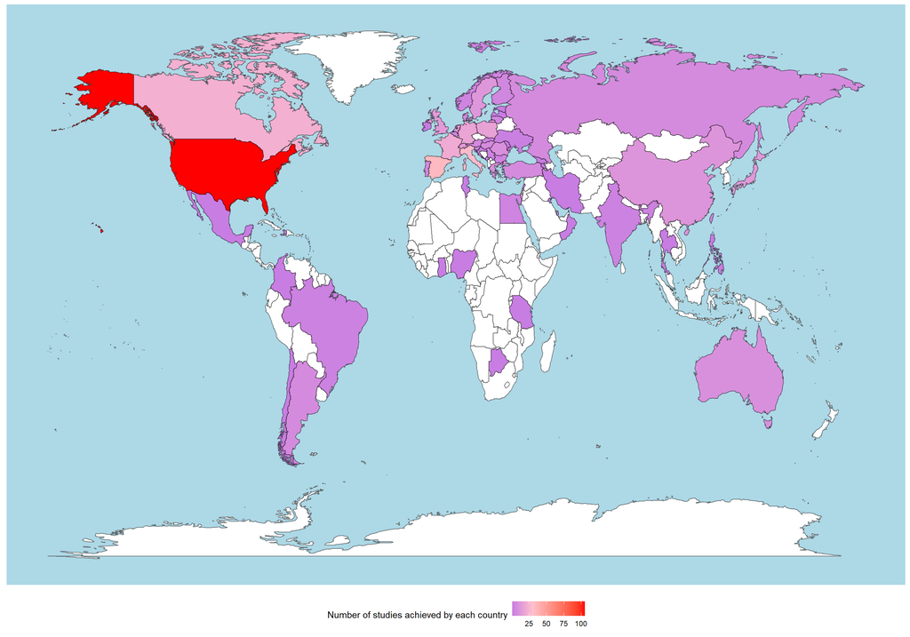

```r
# combine number of studies with a world map
map.world <- map_data("world")

map.world_joined <- left_join(map.world, countries_long, by = c('region' = 'value'))

AHF_map <- ggplot(data = map.world_joined, aes(x = long, y = lat, group = group, fill = n)) +
  geom_polygon(colour = alpha("black", 1/2)) +
theme(text = element_text(family = "Gill Sans", color = "black")
      ,panel.background = element_rect(fill = "lightblue")
      ,plot.background = element_rect(fill = "white")
      ,panel.grid = element_blank()
      ,plot.title = element_text(size = 30)
      ,plot.subtitle = element_text(size = 10)
      ,axis.text = element_blank()
      ,axis.title = element_blank()
      ,axis.ticks = element_blank()
      ,legend.position = "bottom")+
  labs(fill = "Number of studies achieved by each country")+
scale_fill_gradient2(low="blue", mid="pink",midpoint = 30, high="red", na.value="white")
AHF_map
```

```r
ggsave("figures/world_map.tiff", width = 20, height = 15, units = "cm", dpi = 300)
```